# Part II - LOAN DATA FROM PROSPER

> The borrower APR decreases with the better rating. Borrowers with the best Prosper ratings have the lowest APR. It means that the Prosper rating has a strong effect on borrower APR.

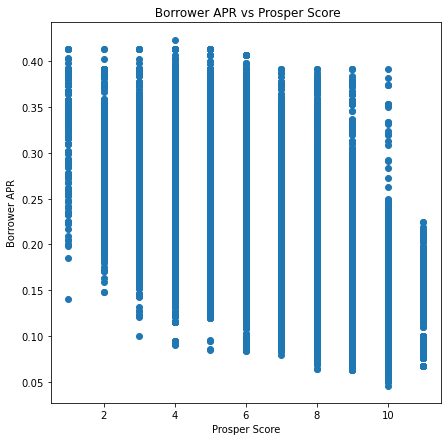

```python
f = plt.figure()
f.set_figwidth(7)
f.set_figheight(7)
plt.scatter(loans.prosper_score, loans.borrower_apr)
plt.title(' Borrower APR vs Prosper Score')
plt.xlabel('Prosper Score')
plt.ylabel('Borrower APR');
```

## Relationship between APR and Debt to Income Ratio

> Again there seems to be no direct correlation between debt_to_income_ratio and APR. However, there is correlation between debt_to_income_ratio and actually getting a loan. Generally people with lower debt to income ratios are more likely to get loans.

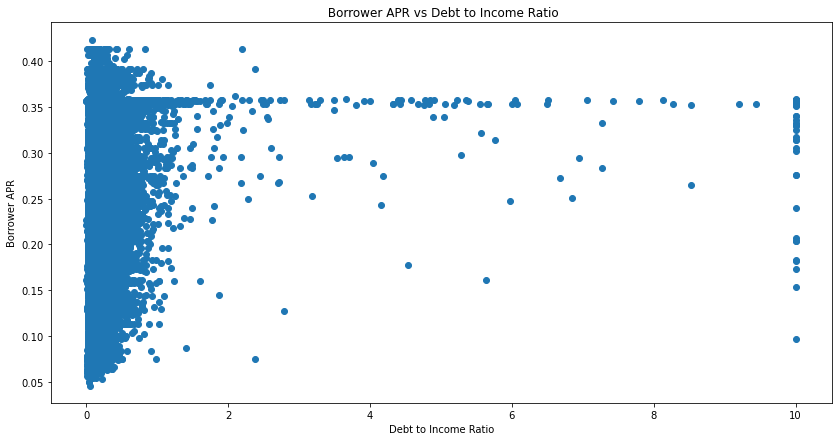

```python
f = plt.figure()
f.set_figwidth(14)
f.set_figheight(7)
plt.scatter(loans.debt_to_income_ratio, loans.borrower_apr)
plt.title(' Borrower APR vs Debt to Income Ratio')
plt.xlabel('Debt to Income Ratio')
plt.ylabel('Borrower APR');
```

## Relationship between APR and Total Prosper Loans

> There also seems to be no direct correlation between Total Prosper Loans and APR. However, there is correlation between Total Prosper Loans and actually getting a loan. Generally people with lower Total Prosper Loans are more likely to get a loan.

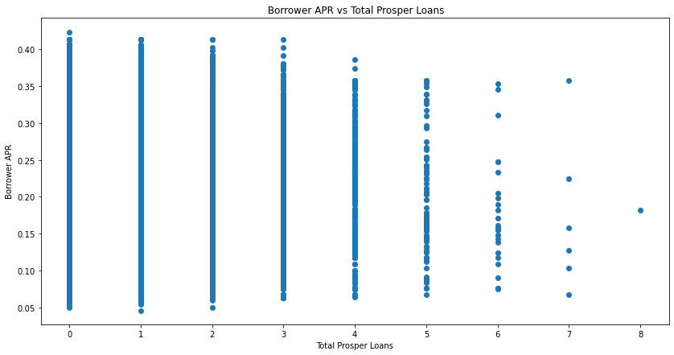

```python
f = plt.figure()
f.set_figwidth(14)
f.set_figheight(7)
plt.scatter(loans.total_prosper_loans, loans.borrower_apr)
plt.title(' Borrower APR vs Total Prosper Loans')
plt.xlabel('Total Prosper Loans')
plt.ylabel('Borrower APR');
```

## Multivatiate Correlation Analysis

It was observed that there is a strong negative correlation between:

1. Prosper rating numeric and borrower_apr
2. prosper score and borrower_apr

Most other correlations exhibited in this dataset are weak.

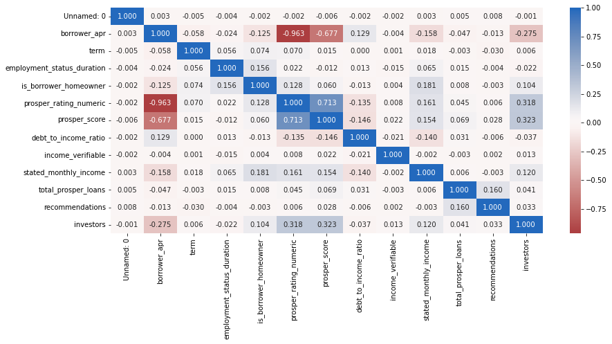

```python
# Plotting the correlation heatmap:
plt.figure(figsize =[14, 6])
sb.heatmap(loans.corr(), annot = True, fmt = '.3f',
           cmap = 'vlag_r', center = 0);
```

```python
!jupyter nbconvert Part_II_slide_deck.ipynb --to slides --post serve --no-input --no-prompt
```

### Credit

The following are credited for the successful development of this project:

1. Udacity nanodegree program in Data Analysis
2. Freecodecamp python for data analysis program
3. Stackoverflow search
4. Python and pandas official documentation
5. Further help from other developers - One on One lessons.